# 77406_SLM_S2021_Report

Maciej Ochota

21 05 2021

# Predictiong term deposit subscribtion after telemarketing campaign

## Abstract

#### In this report I would like to analyse banking telemarketing data and create models which predict whether particular client will subscribe a term deposit. In order to achieve that I will operate in accordance with CRISP-DM standard. Firstly I will try to understand the business processes in banking telemarketing and understand the provided data. Than 3 types of models will be created and assessed. I will skip implementation part as it is academic researc project.

## Introduction

#### In general. There are two approaches to marketing campaigns: mass (traditional) marketing and direct marketing. The mass marketing uses media such as TV, radio or newspapers and direct marketing is performed via mail or phone (telemarketing) (Spiller, 2020). The problem of telemarketing is very important in some sectors of economy, especially in banking, where knowladge about customer needs is crucial (Asif, 2018). Increasing number of telemarketing and in general marketing campaigns has reduced their efficency. Moreover, the bad approach to client may result in negative feedback (Moro, Laureano, Cortez, 2011). On the other hand, proper clients targeting may reduce costs and time of the campaign, so proper prediction of client response is crucial. In this report I will focus on deposit clients and predict whether they will subscribe to term deposit.

## Importing libraries

#### Following R libraries are used in my analysis:

```r
library(mice)
library(ggplot2)
library(VIM)
library(ggpubr)
library(caret)
library(dplyr)
library(ggcorrplot)
library(lemon)
library(kableExtra)
library(MASS)
library(ROCR)
library(rpart)
library(party)
library(nnet)
```

## Data describtion

### Descriptive statistics

#### The data used in this report is derived from Portugese banking insitution telemarketing campaign. The data was colle from 2008 to 2013. In the dataset there are 20 input variables - 10 numeric and 10 cathegorical and output variable - y. The data consists of information about the client, a particular call or whole campaign, product and also about socio-economic situation in Portugal.

#### Summarising the data we can see the describtive statistics for numeric variables and counts of each cathegory for cathegorical ones. It is important to notice, that for some cathegorical variables there is response ‘unknown’. This response will have to be deleted and treated as missing value.

```r
summary(data)
```

```
##       age            job              marital           education
##  Min.   :17.00   Length:41188       Length:41188       Length:41188
##  1st Qu.:32.00   Class :character   Class :character   Class :character
##  Median :38.00   Mode  :character   Mode  :character   Mode  :character
##  Mean   :40.02
##  3rd Qu.:47.00
##  Max.   :98.00
##    default            housing              loan             contact
##  Length:41188       Length:41188       Length:41188       Length:41188
##  Class :character   Class :character   Class :character   Class :character
##  Mode  :character   Mode  :character   Mode  :character   Mode  :character
##
##
##
##     month           day_of_week           duration         campaign
##  Length:41188       Length:41188       Min.   :   0.0   Min.   : 1.000
##  Class :character   Class :character   1st Qu.: 102.0   1st Qu.: 1.000
##  Mode  :character   Mode  :character   Median : 180.0   Median : 2.000
##                                        Mean   : 258.3   Mean   : 2.568
##                                        3rd Qu.: 319.0   3rd Qu.: 3.000
##                                        Max.   :4918.0   Max.   :56.000
##      pdays          previous       poutcome          emp.var.rate
##  Min.   :  0.0   Min.   :0.000   Length:41188       Min.   :-3.40000
##  1st Qu.:999.0   1st Qu.:0.000   Class :character   1st Qu.:-1.80000
##  Median :999.0   Median :0.000   Mode  :character   Median : 1.10000
##  Mean   :962.5   Mean   :0.173                      Mean   : 0.08189
##  3rd Qu.:999.0   3rd Qu.:0.000                      3rd Qu.: 1.40000
##  Max.   :999.0   Max.   :7.000                      Max.   : 1.40000
##  cons.price.idx  cons.conf.idx     euribor3m      nr.employed
##  Min.   :92.20   Min.   :-50.8   Min.   :0.634   Min.   :4964
##  1st Qu.:93.08   1st Qu.:-42.7   1st Qu.:1.344   1st Qu.:5099
##  Median :93.75   Median :-41.8   Median :4.857   Median :5191
##  Mean   :93.58   Mean   :-40.5   Mean   :3.621   Mean   :5167
##  3rd Qu.:93.99   3rd Qu.:-36.4   3rd Qu.:4.961   3rd Qu.:5228
##  Max.   :94.77   Max.   :-26.9   Max.   :5.045   Max.   :5228
##       y
##  Length:41188
##  Class :character
##  Mode  :character
##
##
##
```

#### But, let’s firstly see whethere there are other missing values in the dataset. After performing this chunk of code, we can see that no other missing data was detected.

```r
sum(is.na(data))
```

```
## [1] 0
```

### Plots

#### To explore data more thoroughly I will create the histograms and barplots for each variable.

```r
y_plot <- ggplot(data=data, aes(x=y, y = ..prop.., group = 1))+
  geom_bar(fill="indianred4")+
  ggtitle("Distribution of answers Yes and No ")+
  ylab("Frequency")+
  xlab("Answer")+
  theme(panel.grid = element_blank(),
        panel.background = element_rect(fill="gray98"))
```

```r
age_plot <- ggplot(data=data, aes(x=age))+
  geom_histogram(fill="cornflowerblue", bins = 40)+
  ggtitle("Age distribution")+
  ylab("Frequency")+
  xlab("Age")+
  theme(panel.grid = element_blank(),
        panel.background = element_rect(fill="gray98"))
```

```r
job_plot <- ggplot(data=data, aes(x=job, y = ..prop.., group = 1))+
  geom_bar(fill="cornflowerblue")+
  ggtitle("Job distribution")+
  ylab("Frequency")+
  xlab("Type of job")+
  theme(panel.grid = element_blank(),
        axis.text.x = element_text(angle = 90),
        panel.background = element_rect(fill="gray98"))
```

```r
marital_plot <- ggplot(data=data, aes(x=marital, y = ..prop.., group = 1))+
  geom_bar(fill="cornflowerblue")+
  ggtitle("Marital status distribution")+
  ylab("Frequency")+
  xlab("Marital status")+
  theme(panel.grid = element_blank(),
        panel.background = element_rect(fill="gray98"))
```

```r
education_plot <- ggplot(data=data, aes(x=education, y = ..prop.., group = 1))+
  geom_bar(fill="cornflowerblue")+
  ggtitle("Education level")+
  ylab("Frequency")+
  xlab("Education level")+
  theme(panel.grid = element_blank(),
        axis.text.x = element_text(angle = 90),
        panel.background = element_rect(fill="gray98"))
```

```r
default_plot <- ggplot(data=data, aes(x=default, y = ..prop.., group = 1))+
  geom_bar(fill="cornflowerblue")+
  ggtitle("Has credit in default answers distribution")+
  ylab("Frequency")+
  xlab("Answer")+
  theme(panel.grid = element_blank(),
        panel.background = element_rect(fill="gray98"))
```

```r
housing_plot <- ggplot(data=data, aes(x=housing, y = ..prop.., group = 1))+
  geom_bar(fill="cornflowerblue")+
  ggtitle("Has housing loan answers distribution")+
  ylab("Frequency")+
  xlab("Answer")+
  theme(panel.grid = element_blank(),
        panel.background = element_rect(fill="gray98"))
```

```r
loan_plot <- ggplot(data=data, aes(x=loan, y = ..prop.., group = 1))+
  geom_bar(fill="cornflowerblue")+
  ggtitle("Has personal loan answers distribution")+
  ylab("Frequency")+
  xlab("Answer")+
  theme(panel.grid = element_blank(),
        panel.background = element_rect(fill="gray98"))
```

```r
contact_plot <- ggplot(data=data, aes(x=contact, y = ..prop.., group = 1))+
  geom_bar(fill="cornflowerblue")+
  ggtitle("Contact types distribution")+
  ylab("Frequency")+
  xlab("Contact type")+
  theme(panel.grid = element_blank(),
        panel.background = element_rect(fill="gray98"))
```

```r
month_plot <- ggplot(data=data, aes(x=month, y = ..prop.., group = 1))+
  geom_bar(fill="cornflowerblue")+
  ggtitle("Months of last contact distribution")+
  ylab("Frequency")+
  xlab("Month")+
  theme(panel.grid = element_blank(),
        panel.background = element_rect(fill="gray98"))
```

```r
day_of_week_plot <- ggplot(data=data, aes(x=day_of_week, y = ..prop.., group = 1))+
  geom_bar(fill="cornflowerblue")+
  ggtitle("Days of last contact distribution")+
  ylab("Frequency")+
  xlab("Day of week")+
  theme(panel.grid = element_blank(),
        panel.background = element_rect(fill="gray98"))
```

```r
duration_plot <- ggplot(data=data, aes(x=duration))+
  geom_histogram(fill="cornflowerblue", bins = 40)+
  ggtitle("Last contact duration distribution")+
  ylab("Frequency")+
  xlab("Duration")+
  theme(panel.grid = element_blank(),
        panel.background = element_rect(fill="gray98"))
```

```r
campaign_plot <- ggplot(data=data, aes(x=campaign))+
  geom_histogram(fill="cornflowerblue", bins = 40)+
  ggtitle("Number of contacts distribution")+
  ylab("Frequency")+
  xlab("Number of contacts")+
  theme(panel.grid = element_blank(),
        panel.background = element_rect(fill="gray98"))
```

```r
pdays_plot <- ggplot(data=data, aes(x=pdays))+
  geom_histogram(fill="cornflowerblue", bins = 40)+
  ggtitle("Number of days from last contact distribution")+
  ylab("Frequency")+
  xlab("Number of days")+
  theme(panel.grid = element_blank(),
        panel.background = element_rect(fill="gray98"))
```

```r
previous_plot <- ggplot(data=data, aes(x=previous))+
  geom_histogram(fill="cornflowerblue", bins = 20)+
  ggtitle("Number of contacts befor campaign distribution")+
  ylab("Frequency")+
  xlab("Number of contacts")+
  theme(panel.grid = element_blank(),
        panel.background = element_rect(fill="gray98"))
```

```r
poutcome_plot <- ggplot(data=data, aes(x=poutcome, y = ..prop.., group = 1))+
  geom_bar(fill="cornflowerblue")+
  ggtitle("Outcome of previous campaign distribution")+
  ylab("Frequency")+
  xlab("Outcome")+
  theme(panel.grid = element_blank(),
        panel.background = element_rect(fill="gray98"))
```

```r
emp.var.rate_plot <- ggplot(data=data, aes(x=emp.var.rate))+
  geom_histogram(fill="cornflowerblue", bins = 20)+
  ggtitle("Employment variation rate distribution")+
  ylab("Frequency")+
  xlab("Employment variation rate")+
  theme(panel.grid = element_blank(),
        panel.background = element_rect(fill="gray98"))
```

```r
cons.price.idx_plot <- ggplot(data=data, aes(x=cons.price.idx))+
  geom_histogram(fill="cornflowerblue", bins = 20)+
  ggtitle("Consumer price index distribution")+
  ylab("Frequency")+
  xlab("Consumer price index")+
  theme(panel.grid = element_blank(),
        panel.background = element_rect(fill="gray98"))
```

```r
cons.conf.idx_plot <- ggplot(data=data, aes(x=cons.conf.idx))+
  geom_histogram(fill="cornflowerblue", bins = 20)+
  ggtitle("Consumer confidence index distribution")+
  ylab("Frequency")+
  xlab("Consumer confidence index ")+
  theme(panel.grid = element_blank(),
        panel.background = element_rect(fill="gray98"))
```

```r
euribor3m_plot <- ggplot(data=data, aes(x=euribor3m))+
  geom_histogram(fill="cornflowerblue", bins = 20)+
  ggtitle("3 motnh euribor rate distribution")+
  ylab("Frequency")+
  xlab("Euribor")+
  theme(panel.grid = element_blank(),
        panel.background = element_rect(fill="gray98"))
```

```r
nr.employed_plot <- ggplot(data=data, aes(x=nr.employed))+
  geom_histogram(fill="cornflowerblue", bins = 20)+
  ggtitle("Number of employees distribution")+
  ylab("Frequency")+
  xlab("Number of employees")+
  theme(panel.grid = element_blank(),
        panel.background = element_rect(fill="gray98"))
```

#### Y is target variable in this report. It is binary variable which describes whether the client has subscribed for a term deposit. From this plot we can see that the vast majority of clients has not subscribed for term deposit. It can cause issues as the sample is not balanced. However, those problems can be easily resolved by applying appriopriate threshold.

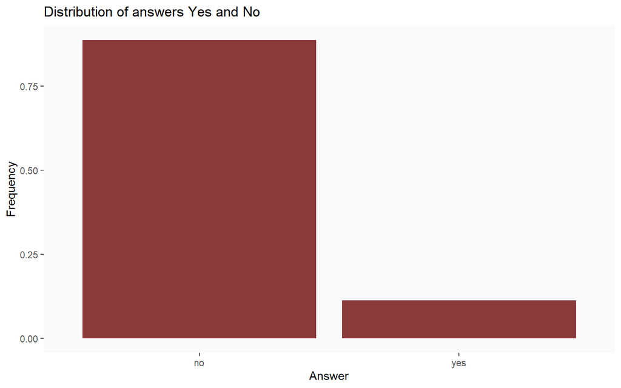

```r
y_plot
```

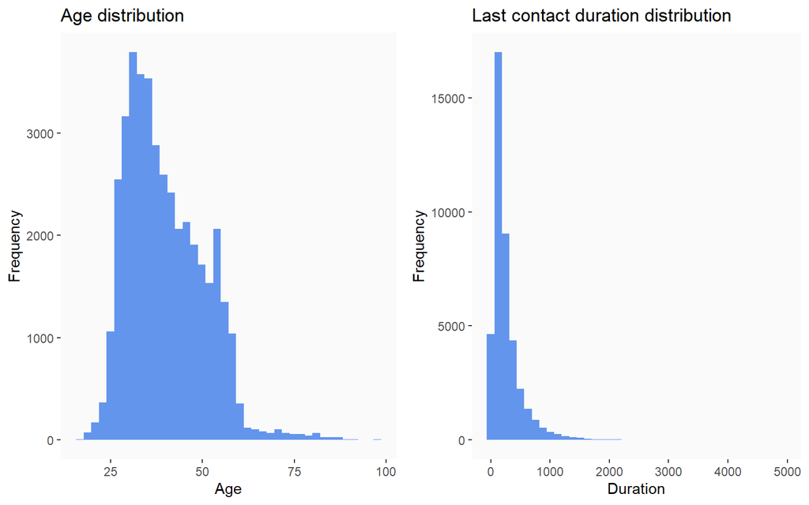

```r
ggarrange(age_plot,duration_plot, ncol = 2, nrow = 1)
```

#### Campaign and pdays are integer variables. First one says how many contacts have been performed for this client and the second one how many days has passed since last contact. The value 999 means that client has never been contacted. We can see that vast majority of clients has never been contacted.

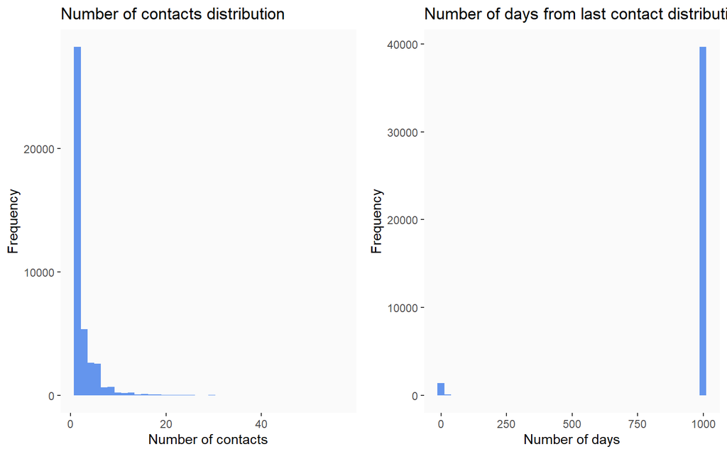

```r
ggarrange(campaign_plot, pdays_plot, ncol = 2, nrow = 1)
```

#### Previous is variable describing number of contacts performed for this client before campaign. Again we can see that vast majority of clients has never been contacted. On the other hand emp.var.rate describes employment variation rate. It is quarterly indicator.

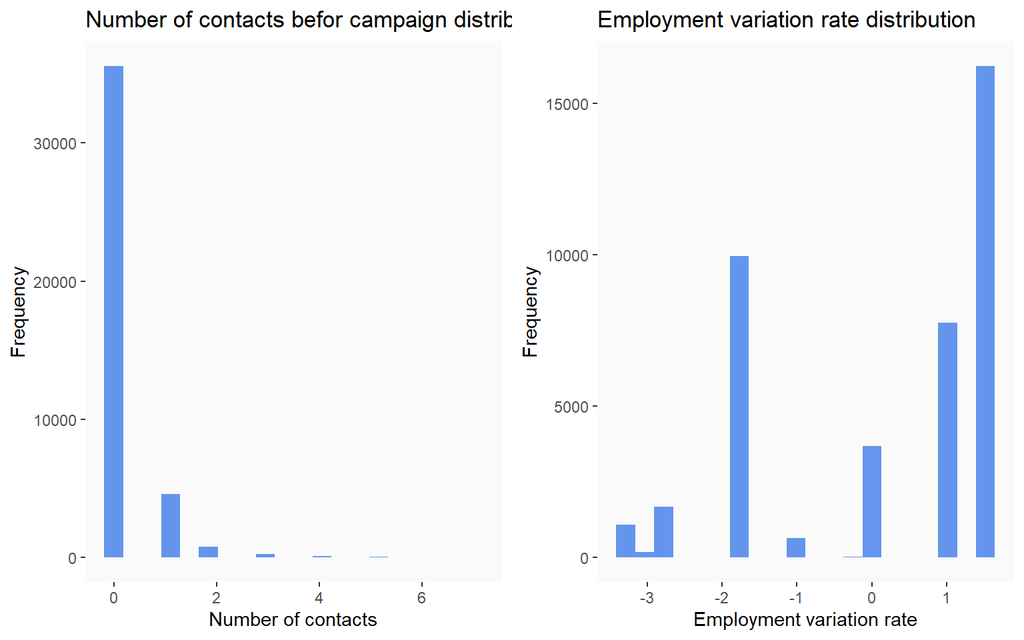

```r
ggarrange(previous_plot, emp.var.rate_plot, ncol = 2, nrow = 1)
```

#### Cons.price.idx and cons.conf.idx describe consumer pricce index and consumer confidance index. CPI measures channges in prices and CCI measures optimism that consumers have towards economy. Both are measured quarterly.

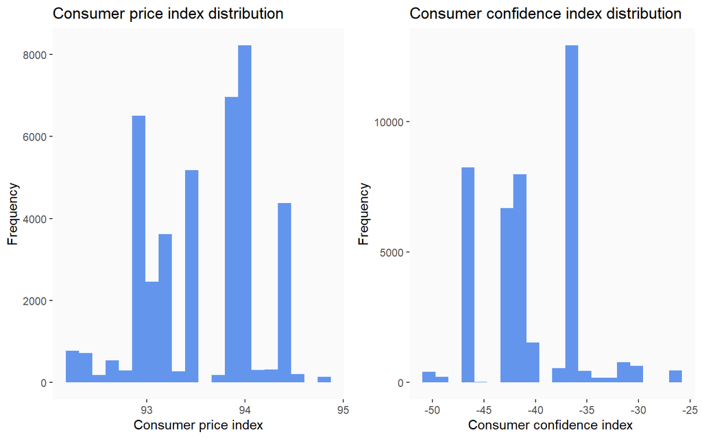

```r
ggarrange(cons.price.idx_plot, cons.conf.idx_plot, ncol = 2, nrow = 1)
```

#### Euribor3m describes the rate at which European banks (operating in Euro currency) lend others funds where loan maturity is 3 months. It is reference rate so it gives information about general interest rates. Nr.employed describes numebr of employees.

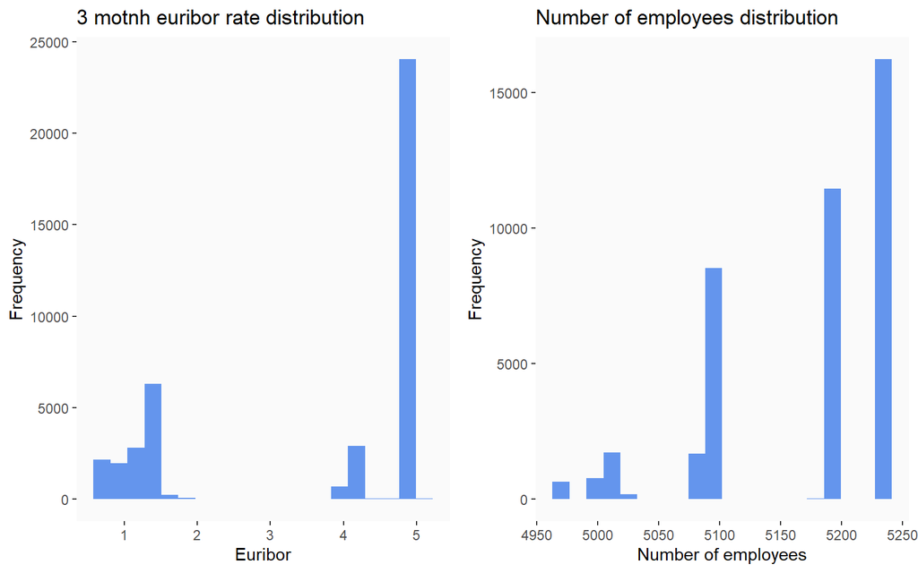

```r
ggarrange(euribor3m_plot, nr.employed_plot,ncol = 2, nrow = 1)
```

#### Housing describes whether the client has housing loan and loan whwther has personal loan. We can see that majority of clients does not have personal loan but have housing loan. Fraction of unknown information is relatively low - below 5%.

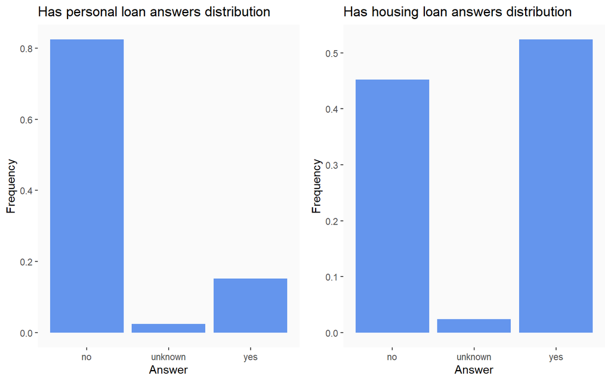

```r
ggarrange(loan_plot, housing_plot,
          ncol = 2, nrow = 1)
```

#### We can see that education level (variable education) has unbalanced distribution of cathegories. To address that issue I will combine several cathegories. Unfortunatelly in 20% of cases we cannot say whether client has credit in default (defalut variable).

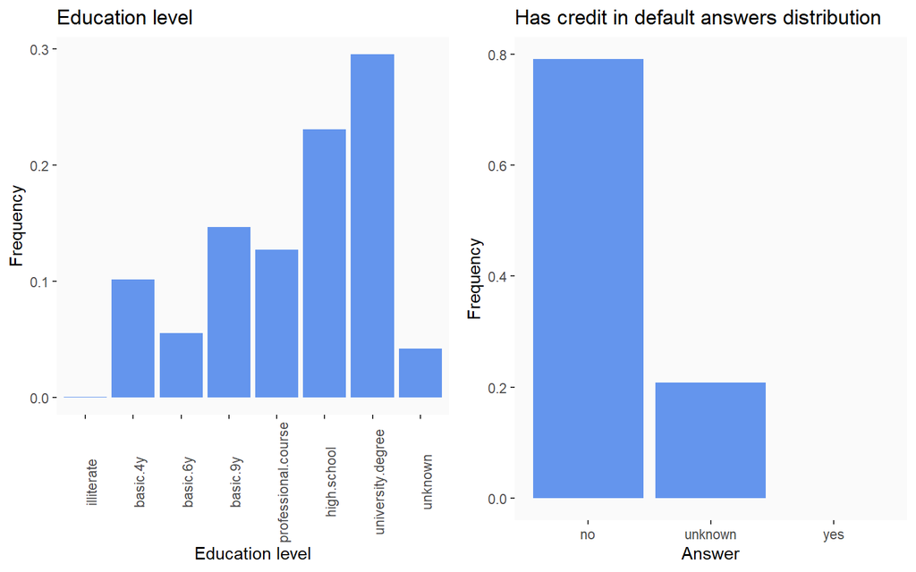

```r
ggarrange(education_plot, default_plot,
          ncol = 2, nrow = 1)
```

#### Again as it was in case of education, type of job has unbalanced cathegories. Cathegories will be combined later in this report. Marital variable describes the marital status of clients. We can see that majority of clients are married.

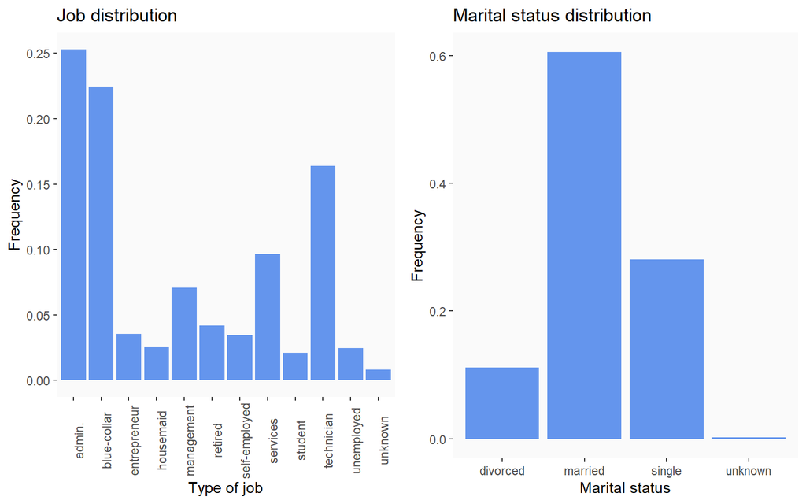

```r
ggarrange(job_plot, marital_plot,
          ncol = 2, nrow = 1)
```

#### Contact describes communication typ. It is categorical variable with cathegories: ‘cellular’,‘telephone’. Poutcome describes whether previous campaign was successfull.

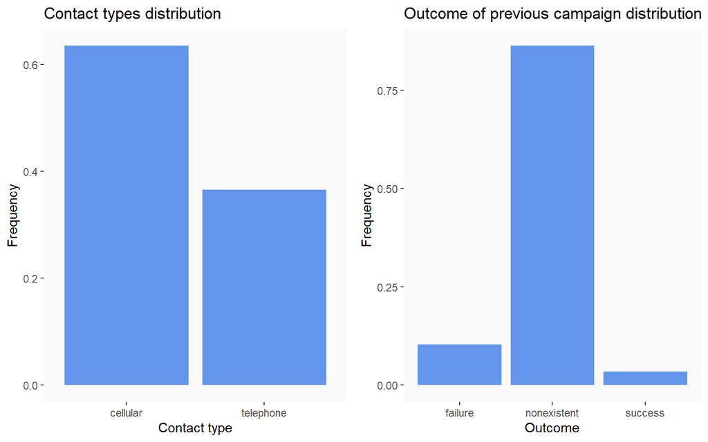

```r
ggarrange(contact_plot,poutcome_plot,
          ncol = 2, nrow = 1)
```

#### Next two variables describe the time of las contact in month of a year (month) or in day of a week (day_of_week).

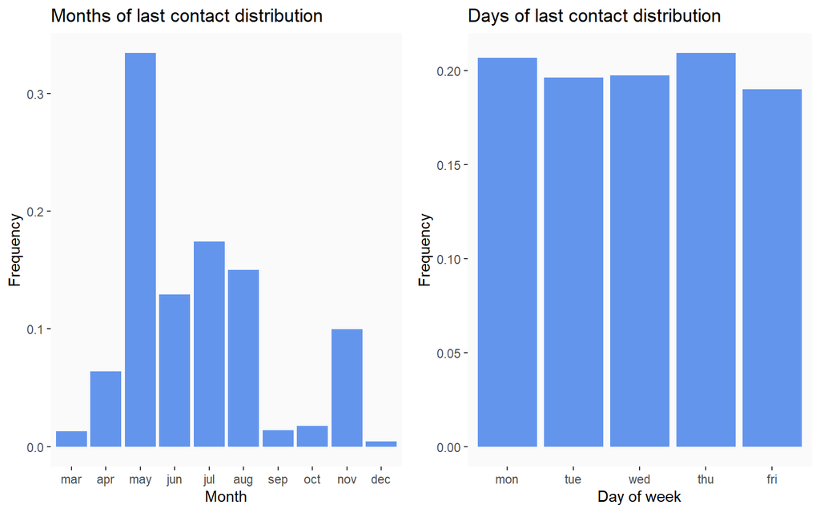

```r
ggarrange(month_plot, day_of_week_plot,
          ncol = 2, nrow = 1)
```

## Data preparation

### Handling with missing data and outliers.

#### After exploring the data I concluded that the distribution of the data is irregular (as it can be seen on previous charts). So that outliers will not be removed from dataset as they can have some predictive value.

#### Firstly, I will handle with ‘unknown’ values. The easiest way to do so is to read once again the data and define “unknown” as missing value. This way we will have appropriate factors in cathegorical variables.

```r
data<-read.csv("bank-additional-full.csv",sep=";", na.strings = "unknown")
```

#### We can see from previous charts that value ‘unknown’ was not that frequent and after replacement we do not have a problem of extensive missing data. In every variable missing data is below 25%. So it is preferable to impute the data rather than delete missing values or whole variable.Firstly, let’s check pattern of missing valuse.

### We can see that majority of data is nonmissing or is missing in only one variable (more than 96% of data). Also the chart does not seem to have any particular pattern. So we do rather have missing at random values.

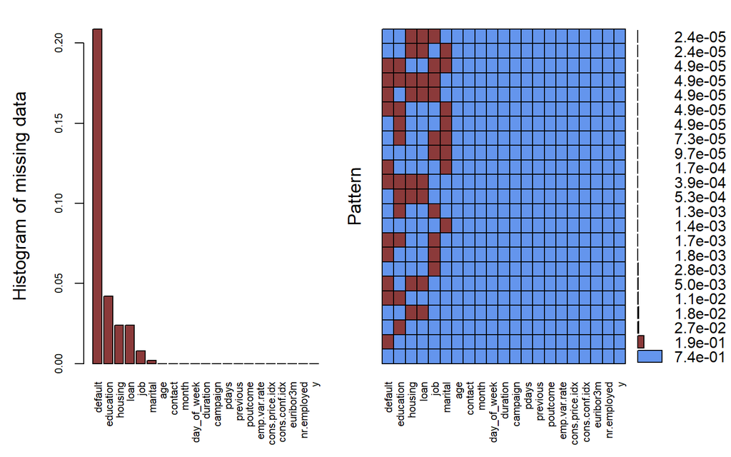

```
##
##  Variables sorted by number of missings:
##        Variable       Count
##         default 0.208725842
##       education 0.042026804
##         housing 0.024036127
##            loan 0.024036127
##             job 0.008012042
##         marital 0.001942313
##             age 0.000000000
##         contact 0.000000000
##           month 0.000000000
##     day_of_week 0.000000000
##        duration 0.000000000
##        campaign 0.000000000
##           pdays 0.000000000
##        previous 0.000000000
##        poutcome 0.000000000
##    emp.var.rate 0.000000000
##  cons.price.idx 0.000000000
##   cons.conf.idx 0.000000000
##       euribor3m 0.000000000
##     nr.employed 0.000000000
##               y 0.000000000
```

```r
aggr_plot <- aggr(data, col=c('cornflowerblue','indianred4'), numbers=TRUE, digits = 8, sortVars=TRUE, labels=names(data), cex.axis=.7, gap=3, ylab=c("Histogram of missing data","Pattern"))
```

#### As we have missing values only in cathegorical variables we have to use appropriate method. I decided to use Decision Trees based method as it is accurate and apropriate for each type of variables.

```r
tempData <- mice(data,m=5,maxit=1,meth='cart',seed=77406)
completedData <- complete(tempData,1)
summary(completedData)
```

```
##       age                 job            marital
##  Min.   :17.00   admin.     :10494   married :24977
##  1st Qu.:32.00   blue-collar: 9329   single  :11592
##  Median :38.00   technician : 6783   divorced: 4619
##  Mean   :40.02   services   : 4007
##  3rd Qu.:47.00   management : 2943
##  Max.   :98.00   retired    : 1760
##                  (Other)    : 5872
##                education     default     housing      loan
##  illiterate         :   20   no :41185   no :19082   no :34769
##  basic.4y           : 4462   yes:    3   yes:22106   yes: 6419
##  basic.6y           : 2410
##  basic.9y           : 6337
##  professional.course: 5458
##  high.school        : 9911
##  university.degree  :12590
##       contact          month       day_of_week    duration
##  cellular :26144   may    :13769   mon:8514    Min.   :   0.0
##  telephone:15044   jul    : 7174   tue:8090    1st Qu.: 102.0
##                    aug    : 6178   wed:8134    Median : 180.0
##                    jun    : 5318   thu:8623    Mean   : 258.3
##                    nov    : 4101   fri:7827    3rd Qu.: 319.0
##                    apr    : 2632               Max.   :4918.0
##                    (Other): 2016
##     campaign          pdays          previous            poutcome
##  Min.   : 1.000   Min.   :  0.0   Min.   :0.000   failure    : 4252
##  1st Qu.: 1.000   1st Qu.:999.0   1st Qu.:0.000   nonexistent:35563
##  Median : 2.000   Median :999.0   Median :0.000   success    : 1373
##  Mean   : 2.568   Mean   :962.5   Mean   :0.173
##  3rd Qu.: 3.000   3rd Qu.:999.0   3rd Qu.:0.000
##  Max.   :56.000   Max.   :999.0   Max.   :7.000
##
##   emp.var.rate      cons.price.idx  cons.conf.idx     euribor3m
##  Min.   :-3.40000   Min.   :92.20   Min.   :-50.8   Min.   :0.634
##  1st Qu.:-1.80000   1st Qu.:93.08   1st Qu.:-42.7   1st Qu.:1.344
##  Median : 1.10000   Median :93.75   Median :-41.8   Median :4.857
##  Mean   : 0.08189   Mean   :93.58   Mean   :-40.5   Mean   :3.621
##  3rd Qu.: 1.40000   3rd Qu.:93.99   3rd Qu.:-36.4   3rd Qu.:4.961
##  Max.   : 1.40000   Max.   :94.77   Max.   :-26.9   Max.   :5.045
##
##   nr.employed        y
##  Min.   :4964   Length:41188
##  1st Qu.:5099   Class :character
##  Median :5191   Mode  :character
##  Mean   :5167
##  3rd Qu.:5228
##  Max.   :5228
##
```

### Combining cathegories

#### As it was described during data exploration, some cathegories require to be combined. Firstly, to make distribution of education level more even I combined all basic levels and illiterate and created cathegory ‘basic’.

#### Moreover, I combined all white-collar jobs, and non-working cathegories (students, house maids, retired and unemployed). Also cathegories of enterprenour and self-employed has been joint. This way I reduced number of cathegories without losing a lot of information.

#### Also, in order to reduce number of cathegories months has been grouped by quarters of the year.

#### We can see that no in all cases it was posible to create even frequent cathegories, but surely the number of them was reduced, which will be helpful during one-hot encoding.

```r
levels(completedData$education)[levels(completedData$education)%in%c("illiterate","basic.4y","basic.6y","basic.9y")] <- "basic"
summary(completedData$education)
```

```
##               basic professional.course         high.school   university.degree
##               13229                5458                9911               12590
```

```r
levels(completedData$job)[levels(completedData$job)%in%c("admin.","management","services","technician")] <- "white-collar"
levels(completedData$job)[levels(completedData$job)%in%c("entrepreneur","self-employed")] <- "entrepreneur/self-employed"
levels(completedData$job)[levels(completedData$job)%in%c("student","retired","housemaid","unemployed")] <- "not-working"
summary(completedData$job)
```

```
##               white-collar                blue-collar
##                      24227                       9329
## entrepreneur/self-employed                not-working
##                       2898                       4734
```

```r
levels(completedData$month)[levels(completedData$month)%in%c("jan","feb","mar")] <- "IQ"
levels(completedData$month)[levels(completedData$month)%in%c("apr","may","jun")] <- "IIQ"
levels(completedData$month)[levels(completedData$month)%in%c("jul","aug","sep")] <- "IIIQ"
levels(completedData$month)[levels(completedData$month)%in%c("oct","nov","dec")] <- "IVQ"
completedData$month <- factor(completedData$month, levels = c("IIQ","IIIQ","IVQ","IQ"))
summary(completedData$month)
```

```
##   IIQ  IIIQ   IVQ    IQ
## 21719 13922  5001   546
```

### Data standardization

#### As I plan to use neural networks it is necesary to standardize all numeric variables.

```r
standarized <- completedData%>%mutate_if(is.numeric,scale)
summary(standarized)
```

```
##        age.V1                                job            marital
##  Min.   :-2.209338   white-collar              :24227   married :24977
##  1st Qu.:-0.769971   blue-collar               : 9329   single  :11592
##  Median :-0.194224   entrepreneur/self-employed: 2898   divorced: 4619
##  Mean   : 0.000000   not-working               : 4734
##  3rd Qu.: 0.669396
##  Max.   : 5.563242
##                education     default     housing      loan
##  basic              :13229   no :41185   no :19082   no :34769
##  professional.course: 5458   yes:    3   yes:22106   yes: 6419
##  high.school        : 9911
##  university.degree  :12590
##
##
##       contact       month       day_of_week     duration.V1
##  cellular :26144   IIQ :21719   mon:8514    Min.   :-0.996165
##  telephone:15044   IIIQ:13922   tue:8090    1st Qu.:-0.602767
##                    IVQ : 5001   wed:8134    Median :-0.301933
##                    IQ  :  546   thu:8623    Mean   : 0.000000
##                                 fri:7827    3rd Qu.: 0.234168
##                                             Max.   :17.971801
##      campaign.V1          pdays.V1           previous.V1
##  Min.   :-0.565915   Min.   :-5.149381   Min.   :-0.349490
##  1st Qu.:-0.565915   1st Qu.: 0.195412   1st Qu.:-0.349490
##  Median :-0.204906   Median : 0.195412   Median :-0.349490
##  Mean   : 0.000000   Mean   : 0.000000   Mean   : 0.000000
##  3rd Qu.: 0.156103   3rd Qu.: 0.195412   3rd Qu.:-0.349490
##  Max.   :19.289583   Max.   : 0.195412   Max.   :13.794751
##         poutcome       emp.var.rate.V1     cons.price.idx.V1
##  failure    : 4252   Min.   :-2.2164066   Min.   :-2.3748605
##  nonexistent:35563   1st Qu.:-1.1979209   1st Qu.:-0.8649442
##  success    : 1373   Median : 0.6480844   Median : 0.2994534
##                      Mean   : 0.0000000   Mean   : 0.0000000
##                      3rd Qu.: 0.8390505   3rd Qu.: 0.7227137
##                      Max.   : 0.8390505   Max.   : 2.0581431
##    cons.conf.idx.V1       euribor3m.V1        nr.employed.V1
##  Min.   :-2.2249264   Min.   :-1.7223300   Min.   :-2.8156624
##  1st Qu.:-0.4747852   1st Qu.:-1.3129777   1st Qu.:-0.9402695
##  Median :-0.2803250   Median : 0.7124512   Median : 0.3316759
##  Mean   : 0.0000000   Mean   : 0.0000000   Mean   : 0.0000000
##  3rd Qu.: 0.8864358   3rd Qu.: 0.7724127   3rd Qu.: 0.8451598
##  Max.   : 2.9390706   Max.   : 0.8208431   Max.   : 0.8451598
##       y
##  Length:41188
##  Class :character
##  Mode  :character
##
##
##
```

### One hot encoding

#### In order to be able to use cathegorical data it is needed to perform one-hot encoding. To do so I changed every variable with n cathegories into n-1 variables. So if variable has 3 cathegories in the new data set there will be 1 more.The reference cathegories was chosen on basis of frequency (most frequent ones) or the order (most basic ones as in education or the oldest one as in day of week).

```r
dummy <- dummyVars(" ~ .", data=standarized, fullRank = TRUE)
newdata <- data.frame(predict(dummy, newdata = standarized))
summary(standarized)
```

```
##        age.V1                                job            marital
##  Min.   :-2.209338   white-collar              :24227   married :24977
##  1st Qu.:-0.769971   blue-collar               : 9329   single  :11592
##  Median :-0.194224   entrepreneur/self-employed: 2898   divorced: 4619
##  Mean   : 0.000000   not-working               : 4734
##  3rd Qu.: 0.669396
##  Max.   : 5.563242
##                education     default     housing      loan
##  basic              :13229   no :41185   no :19082   no :34769
##  professional.course: 5458   yes:    3   yes:22106   yes: 6419
##  high.school        : 9911
##  university.degree  :12590
##
##
##       contact       month       day_of_week     duration.V1
##  cellular :26144   IIQ :21719   mon:8514    Min.   :-0.996165
##  telephone:15044   IIIQ:13922   tue:8090    1st Qu.:-0.602767
##                    IVQ : 5001   wed:8134    Median :-0.301933
##                    IQ  :  546   thu:8623    Mean   : 0.000000
##                                 fri:7827    3rd Qu.: 0.234168
##                                             Max.   :17.971801
##      campaign.V1          pdays.V1           previous.V1
##  Min.   :-0.565915   Min.   :-5.149381   Min.   :-0.349490
##  1st Qu.:-0.565915   1st Qu.: 0.195412   1st Qu.:-0.349490
##  Median :-0.204906   Median : 0.195412   Median :-0.349490
##  Mean   : 0.000000   Mean   : 0.000000   Mean   : 0.000000
##  3rd Qu.: 0.156103   3rd Qu.: 0.195412   3rd Qu.:-0.349490
##  Max.   :19.289583   Max.   : 0.195412   Max.   :13.794751
##         poutcome       emp.var.rate.V1     cons.price.idx.V1
##  failure    : 4252   Min.   :-2.2164066   Min.   :-2.3748605
##  nonexistent:35563   1st Qu.:-1.1979209   1st Qu.:-0.8649442
##  success    : 1373   Median : 0.6480844   Median : 0.2994534
##                      Mean   : 0.0000000   Mean   : 0.0000000
##                      3rd Qu.: 0.8390505   3rd Qu.: 0.7227137
##                      Max.   : 0.8390505   Max.   : 2.0581431
##    cons.conf.idx.V1       euribor3m.V1        nr.employed.V1
##  Min.   :-2.2249264   Min.   :-1.7223300   Min.   :-2.8156624
##  1st Qu.:-0.4747852   1st Qu.:-1.3129777   1st Qu.:-0.9402695
##  Median :-0.2803250   Median : 0.7124512   Median : 0.3316759
##  Mean   : 0.0000000   Mean   : 0.0000000   Mean   : 0.0000000
##  3rd Qu.: 0.8864358   3rd Qu.: 0.7724127   3rd Qu.: 0.8451598
##  Max.   : 2.9390706   Max.   : 0.8208431   Max.   : 0.8451598
##       y
##  Length:41188
##  Class :character
##  Mode  :character
##
##
##
```

```r
for (i in c(2:20,25:26,32)){
 newdata[,i]<-as.logical(newdata[,i])
}
```

## Final dataset exploration

#### As I would like to explore the relation between variables I have to devide them into two cathegoris - numerical and cathegorical.

```r
numeric<-newdata[-c(2:20,25:26,32)]
summary(newdata)
```

```
##       age          job.blue.collar job.entrepreneur.self.employed
##  Min.   :-2.2093   Mode :logical   Mode :logical
##  1st Qu.:-0.7700   FALSE:31859     FALSE:38290
##  Median :-0.1942   TRUE :9329      TRUE :2898
##  Mean   : 0.0000
##  3rd Qu.: 0.6694
##  Max.   : 5.5632
##  job.not.working marital.single  marital.divorced education.professional.course
##  Mode :logical   Mode :logical   Mode :logical    Mode :logical
##  FALSE:36454     FALSE:29596     FALSE:36569      FALSE:35730
##  TRUE :4734      TRUE :11592     TRUE :4619       TRUE :5458
##
##
##
##  education.high.school education.university.degree default.yes
##  Mode :logical         Mode :logical               Mode :logical
##  FALSE:31277           FALSE:28598                 FALSE:41185
##  TRUE :9911            TRUE :12590                 TRUE :3
##
##
##
##  housing.yes      loan.yes       contact.telephone month.IIIQ
##  Mode :logical   Mode :logical   Mode :logical     Mode :logical
##  FALSE:19082     FALSE:34769     FALSE:26144       FALSE:27266
##  TRUE :22106     TRUE :6419      TRUE :15044       TRUE :13922
##
##
##
##  month.IVQ        month.IQ       day_of_week.tue day_of_week.wed
##  Mode :logical   Mode :logical   Mode :logical   Mode :logical
##  FALSE:36187     FALSE:40642     FALSE:33098     FALSE:33054
##  TRUE :5001      TRUE :546       TRUE :8090      TRUE :8134
##
##
##
##  day_of_week.thu day_of_week.fri    duration          campaign
##  Mode :logical   Mode :logical   Min.   :-0.9962   Min.   :-0.5659
##  FALSE:32565     FALSE:33361     1st Qu.:-0.6028   1st Qu.:-0.5659
##  TRUE :8623      TRUE :7827      Median :-0.3019   Median :-0.2049
##                                  Mean   : 0.0000   Mean   : 0.0000
```

[output cut: 8 more lines]

```
##  Max.   : 0.1954   Max.   :13.7948
##   emp.var.rate     cons.price.idx    cons.conf.idx       euribor3m
##  Min.   :-2.2164   Min.   :-2.3749   Min.   :-2.2249   Min.   :-1.7223
##  1st Qu.:-1.1979   1st Qu.:-0.8649   1st Qu.:-0.4748   1st Qu.:-1.3130
##  Median : 0.6481   Median : 0.2995   Median :-0.2803   Median : 0.7125
##  Mean   : 0.0000   Mean   : 0.0000   Mean   : 0.0000   Mean   : 0.0000
##  3rd Qu.: 0.8391   3rd Qu.: 0.7227   3rd Qu.: 0.8864   3rd Qu.: 0.7724
##  Max.   : 0.8391   Max.   : 2.0581   Max.   : 2.9391   Max.   : 0.8208
##   nr.employed         yyes
##  Min.   :-2.8157   Mode :logical
##  1st Qu.:-0.9403   FALSE:36548
##  Median : 0.3317   TRUE :4640
##  Mean   : 0.0000
##  3rd Qu.: 0.8452
##  Max.   : 0.8452
```

### Numerical variables - density

#### In this paragraph I create histogram of each standardized numerical variables with density estimation.

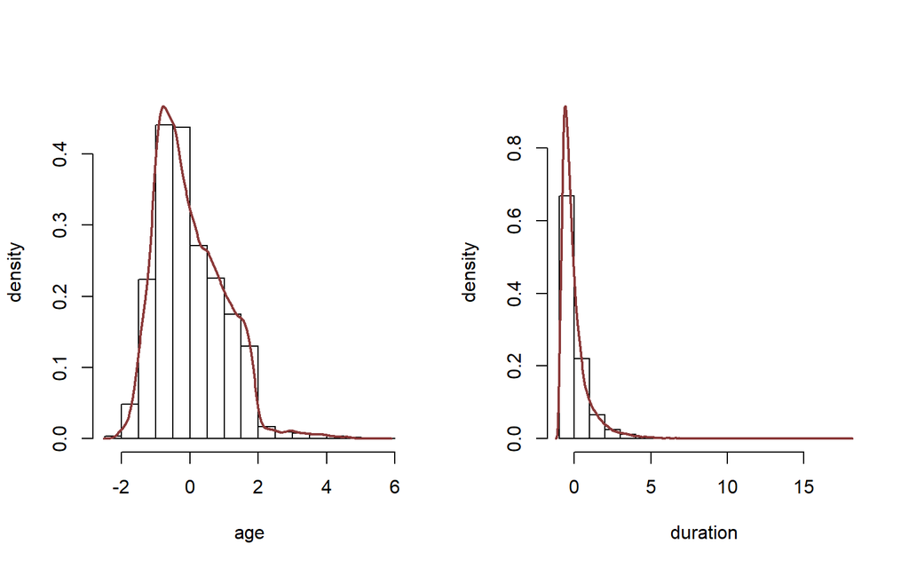

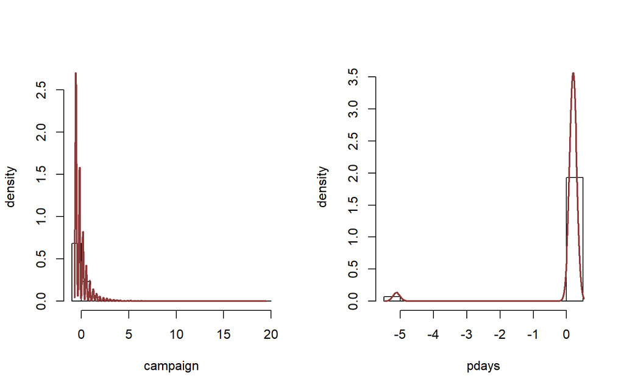

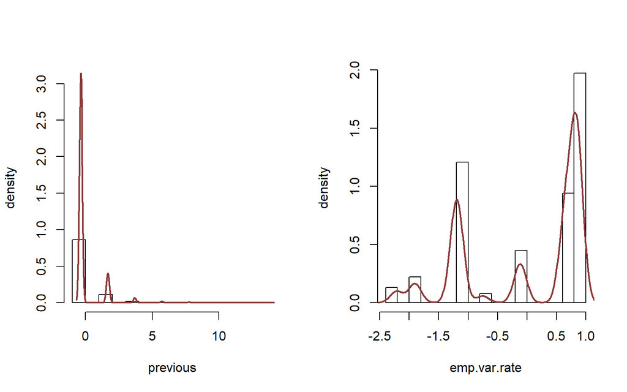

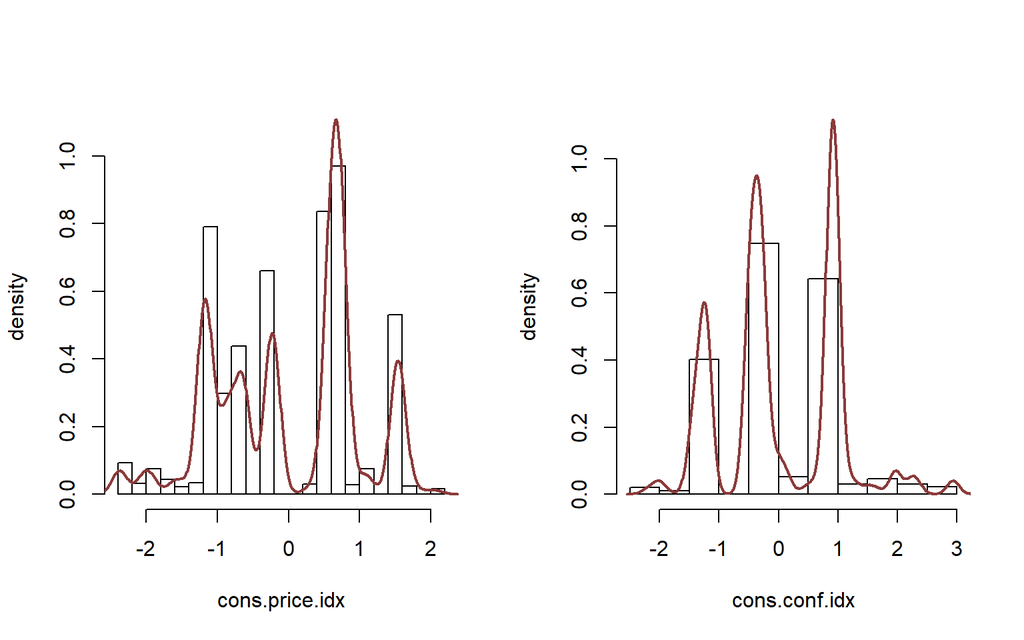

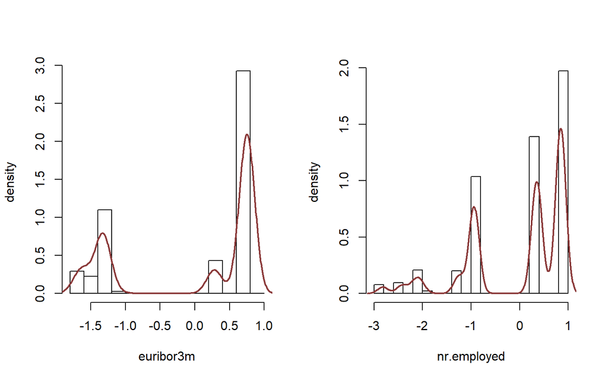

```r
OptimizeMfrow <- function(elements) {
  columns <- ceiling(sqrt(elements))
  rows <- ifelse(columns * (columns - 1) < elements, columns, columns - 1)
  return(c(rows, columns))
}



DoHistogram <- function(values, values.name) {
  histogram <- hist(values, plot = FALSE)
  density.estimate <- density(values)
  y.maximum <- max(histogram$density, density.estimate$y)
  plot(histogram, freq = FALSE, ylim = c(0, y.maximum),
       xlab = values.name, ylab = "density", main = NULL)
  lines(density.estimate, lwd = 2, col="indianred4")
}

par(mfrow = c(1,2))
invisible(mapply(DoHistogram, numeric, names(numeric)))
```

```r
head(numeric)
```

```
##            age   duration   campaign     pdays previous emp.var.rate
## 1  1.533015677  0.0104713 -0.5659151 0.1954115 -0.34949    0.6480844
## 2  1.628973456 -0.4214954 -0.5659151 0.1954115 -0.34949    0.6480844
## 3 -0.290182119 -0.1245183 -0.5659151 0.1954115 -0.34949    0.6480844
## 4 -0.002308783 -0.4137817 -0.5659151 0.1954115 -0.34949    0.6480844
## 5  1.533015677  0.1878862 -0.5659151 0.1954115 -0.34949    0.6480844
## 6  0.477480111 -0.2325100 -0.5659151 0.1954115 -0.34949    0.6480844
##   cons.price.idx cons.conf.idx euribor3m nr.employed
## 1      0.7227137     0.8864358 0.7124512   0.3316759
## 2      0.7227137     0.8864358 0.7124512   0.3316759
## 3      0.7227137     0.8864358 0.7124512   0.3316759
## 4      0.7227137     0.8864358 0.7124512   0.3316759
## 5      0.7227137     0.8864358 0.7124512   0.3316759
## 6      0.7227137     0.8864358 0.7124512   0.3316759
```

```r
par(mfrow = c(1,2))
for (i in colnames(numeric)){
ggplot(newdata, aes(x = newdata[[i]], fill = yyes)) +
  geom_histogram(position = "identity", alpha = 0.4, bins = 20)
}
```

### Numerical variables - Correlation matrix

#### On the plot bolow we can see correlation matrix. Several variables are highly correlated. So I decided to remove nr.employed and emp.var.rate from the dataset as I believe that those values are based on euribor3m rate.

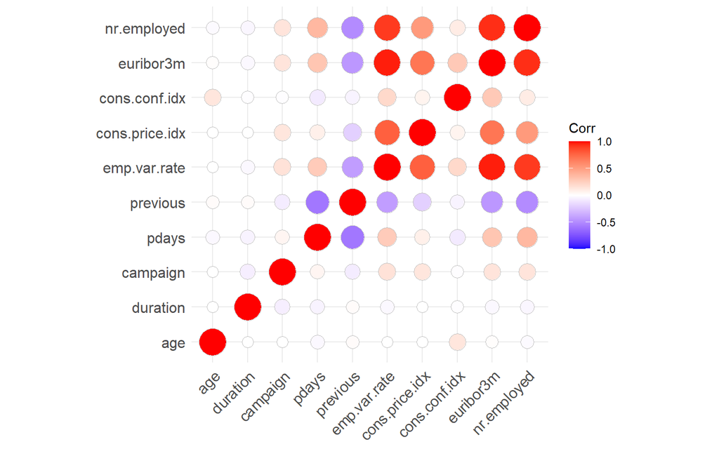

```r
corr <- round(cor(numeric), 3)
ggcorrplot(corr, method = "circle")
```

```r
drop <- c("emp.var.rate","nr.employed")
newdata = newdata[,!(names(newdata) %in% drop)]
summary(newdata)
```

```
##       age          job.blue.collar job.entrepreneur.self.employed
##  Min.   :-2.2093   Mode :logical   Mode :logical
##  1st Qu.:-0.7700   FALSE:31859     FALSE:38290
##  Median :-0.1942   TRUE :9329      TRUE :2898
##  Mean   : 0.0000
##  3rd Qu.: 0.6694
##  Max.   : 5.5632
##  job.not.working marital.single  marital.divorced education.professional.course
##  Mode :logical   Mode :logical   Mode :logical    Mode :logical
##  FALSE:36454     FALSE:29596     FALSE:36569      FALSE:35730
##  TRUE :4734      TRUE :11592     TRUE :4619       TRUE :5458
##
##
##
##  education.high.school education.university.degree default.yes
##  Mode :logical         Mode :logical               Mode :logical
##  FALSE:31277           FALSE:28598                 FALSE:41185
##  TRUE :9911            TRUE :12590                 TRUE :3
##
##
##
##  housing.yes      loan.yes       contact.telephone month.IIIQ
##  Mode :logical   Mode :logical   Mode :logical     Mode :logical
##  FALSE:19082     FALSE:34769     FALSE:26144       FALSE:27266
##  TRUE :22106     TRUE :6419      TRUE :15044       TRUE :13922
##
##
##
##  month.IVQ        month.IQ       day_of_week.tue day_of_week.wed
##  Mode :logical   Mode :logical   Mode :logical   Mode :logical
##  FALSE:36187     FALSE:40642     FALSE:33098     FALSE:33054
##  TRUE :5001      TRUE :546       TRUE :8090      TRUE :8134
##
##
##
##  day_of_week.thu day_of_week.fri    duration          campaign
##  Mode :logical   Mode :logical   Min.   :-0.9962   Min.   :-0.5659
##  FALSE:32565     FALSE:33361     1st Qu.:-0.6028   1st Qu.:-0.5659
##  TRUE :8623      TRUE :7827      Median :-0.3019   Median :-0.2049
##                                  Mean   : 0.0000   Mean   : 0.0000
##                                  3rd Qu.: 0.2342   3rd Qu.: 0.1561
##                                  Max.   :17.9718   Max.   :19.2896
##      pdays            previous       poutcome.nonexistent poutcome.success
##  Min.   :-5.1494   Min.   :-0.3495   Mode :logical        Mode :logical
##  1st Qu.: 0.1954   1st Qu.:-0.3495   FALSE:5625           FALSE:39815
##  Median : 0.1954   Median :-0.3495   TRUE :35563          TRUE :1373
##  Mean   : 0.0000   Mean   : 0.0000
##  3rd Qu.: 0.1954   3rd Qu.:-0.3495
##  Max.   : 0.1954   Max.   :13.7948
##  cons.price.idx    cons.conf.idx       euribor3m          yyes
##  Min.   :-2.3749   Min.   :-2.2249   Min.   :-1.7223   Mode :logical
##  1st Qu.:-0.8649   1st Qu.:-0.4748   1st Qu.:-1.3130   FALSE:36548
##  Median : 0.2995   Median :-0.2803   Median : 0.7125   TRUE :4640
##  Mean   : 0.0000   Mean   : 0.0000   Mean   : 0.0000
##  3rd Qu.: 0.7227   3rd Qu.: 0.8864   3rd Qu.: 0.7724
##  Max.   : 2.0581   Max.   : 2.9391   Max.   : 0.8208
```

### Cathegorical variables - relation with target

#### On the plots bolow we can see relation between each cathegorical variable and target. It can be seen that for majority of variables diffrences in y values among cathegories is not substantial. However there are variables such as poutcome where diffrences can be easily seen.

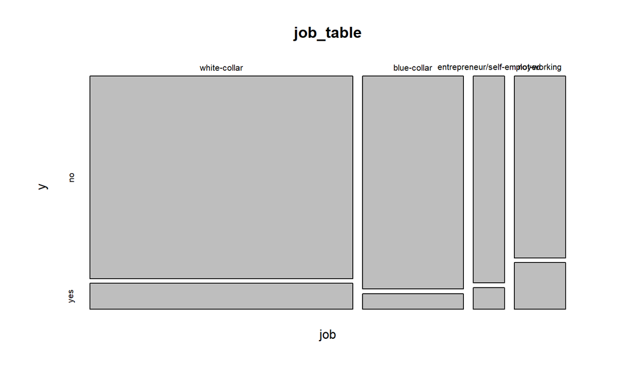

```r
par(mfrow = c(1,1))

job_table <- table(completedData$job,completedData$y,dnn=c("job","y"))
mosaicplot(job_table)
```

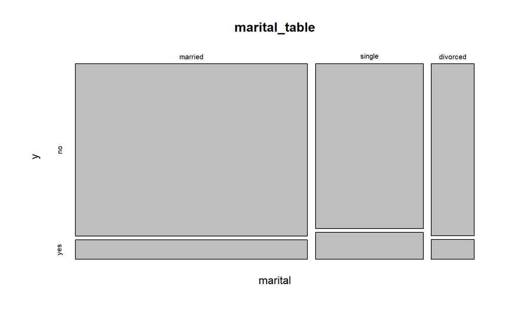

```r
marital_table <- table(completedData$marital,completedData$y,dnn=c("marital","y"))
mosaicplot(marital_table)
```

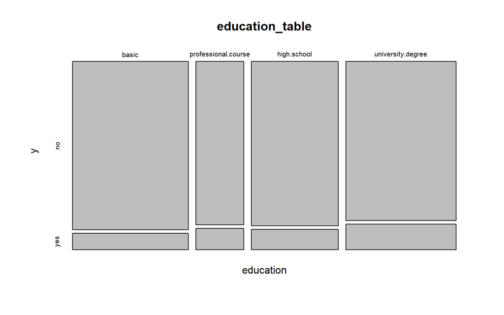

```r
education_table <- table(completedData$education,completedData$y,dnn=c("education","y"))
mosaicplot(education_table)
```

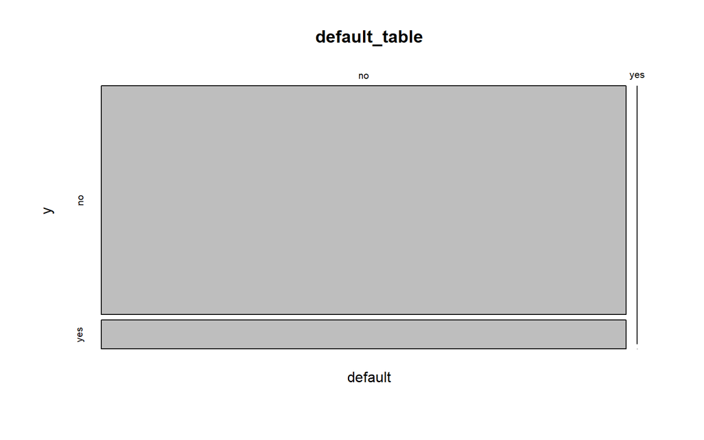

```r
default_table <- table(completedData$default,completedData$y,dnn=c("default","y"))
mosaicplot(default_table)
```

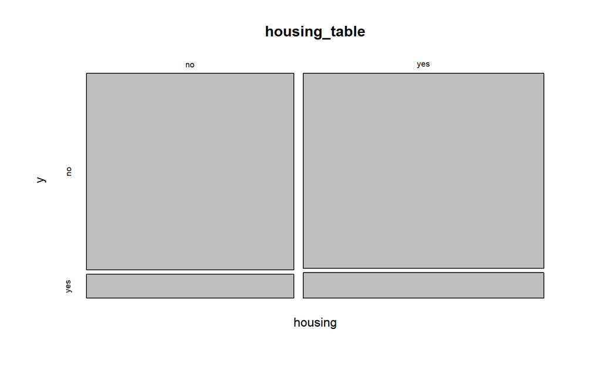

```r
housing_table <- table(completedData$housing,completedData$y,dnn=c("housing","y"))
mosaicplot(housing_table)
```

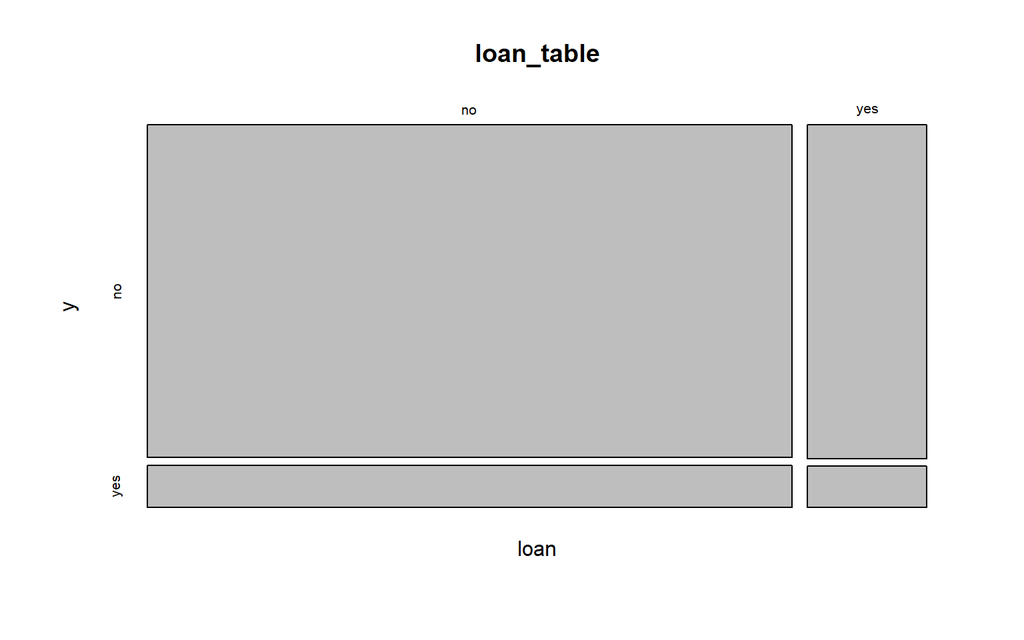

```r
loan_table <- table(completedData$loan,completedData$y,dnn=c("loan","y"))
mosaicplot(loan_table)
```

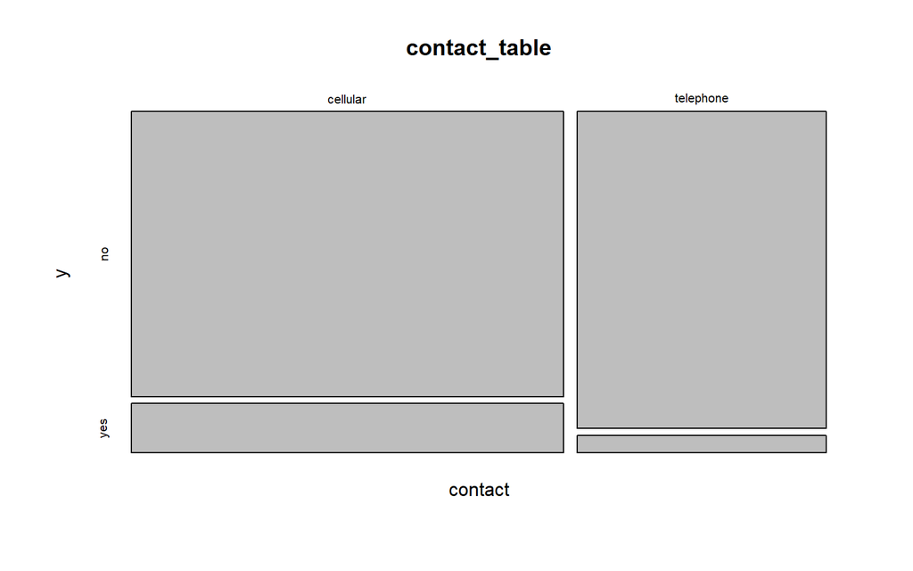

```r
contact_table <- table(completedData$contact,completedData$y,dnn=c("contact","y"))
mosaicplot(contact_table)
```

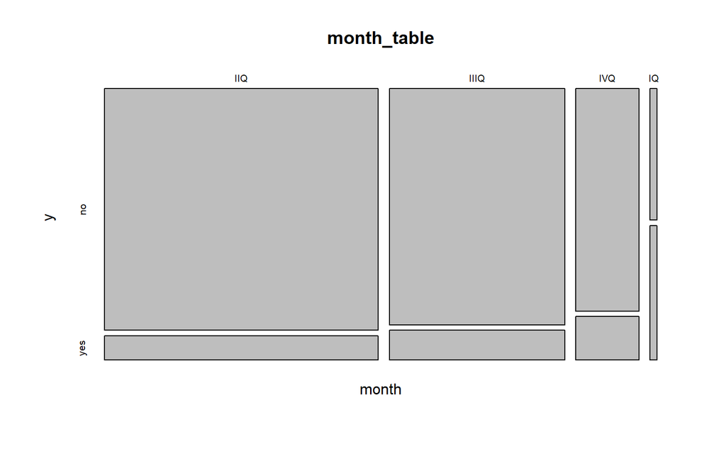

```r
month_table <- table(completedData$month,completedData$y,dnn=c("month","y"))
mosaicplot(month_table)
```

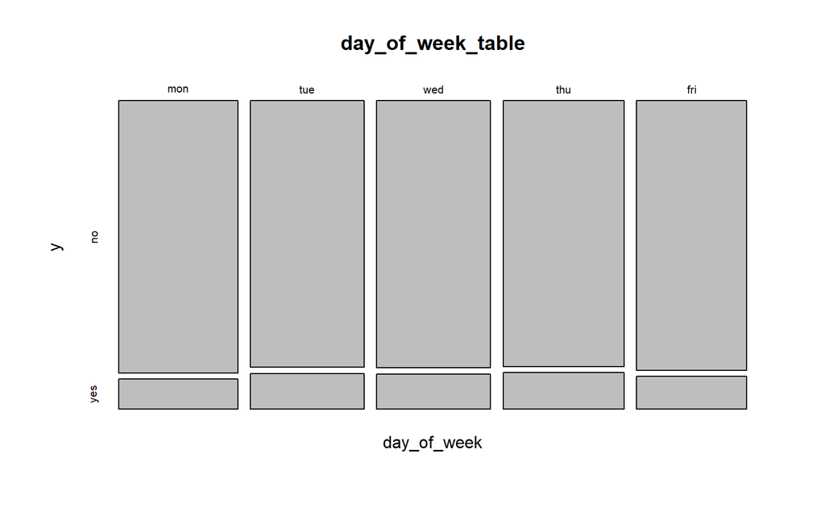

```r
day_of_week_table <- table(completedData$day_of_week,completedData$y,dnn=c("day_of_week","y"))
mosaicplot(day_of_week_table)
```

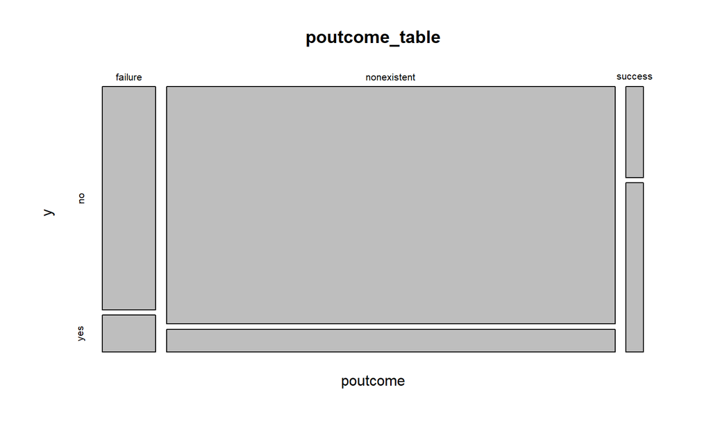

```r
poutcome_table <- table(completedData$poutcome,completedData$y,dnn=c("poutcome","y"))
mosaicplot(poutcome_table)
```

## Modeling

### Splitting the data

#### In order to properly evaluate the model I splitted data into 3 parts: training, validation and testing. On training which consists of 70% of data each model will be trained and validated on validation set (15%) to check if model is not over fitted. To choose the best model I will use test set (also 15% of data).

```r
set.seed(77406)

SplitDataSet <- function(data.set, training.fraction, test.fraction){
  random.numbers <- sample.int(nrow(data.set))
  quantiles <- quantile(random.numbers, probs = c(0, test.fraction, training.fraction, 1))
  split.labels <- cut(random.numbers, quantiles, include.lowest = T,
                      labels = c("test", "training", "validation"))
  return(split(data.set, split.labels))
}

set <- SplitDataSet(newdata,0.85,0.15)
training <- set$training
test <- set$test
validation <- set$validation

nrow(validation)/nrow(data)
```

```
## [1] 0.1500194
```

```r
head(training)
```

```
##             age job.blue.collar job.entrepreneur.self.employed job.not.working
## 1   1.533015677           FALSE                          FALSE            TRUE
## 4  -0.002308783           FALSE                          FALSE           FALSE
## 5   1.533015677           FALSE                          FALSE           FALSE
## 8   0.093648996            TRUE                          FALSE           FALSE
## 10 -1.441675464           FALSE                          FALSE           FALSE
## 11  0.093648996            TRUE                          FALSE           FALSE
##    marital.single marital.divorced education.professional.course
## 1           FALSE            FALSE                         FALSE
## 4           FALSE            FALSE                         FALSE
## 5           FALSE            FALSE                         FALSE
## 8           FALSE            FALSE                         FALSE
## 10           TRUE            FALSE                         FALSE
## 11          FALSE            FALSE                          TRUE
##    education.high.school education.university.degree default.yes housing.yes
```

[output cut: 34 more lines]

### Stepwise logistic regression

#### I created 3 stepwise regression. One backwards, one forwards and one in both ways. Each of these methods have selected the same variables.

```r
full_model <- glm(yyes ~., data = training, family = "binomial")

zero_model <- glm(yyes ~1, data = training, family = "binomial")

back_model <- stepAIC(full_model, direction = "backward",trace = FALSE)
both_model <- stepAIC(zero_model,scope=list(lower=formula(zero_model),upper=formula(full_model)), direction="both", trace = FALSE)
for_model <- stepAIC(zero_model,scope=list(lower=formula(zero_model),upper=formula(full_model)), direction="forward", trace = FALSE)


formula(both_model)
```

```
## yyes ~ duration + euribor3m + pdays + cons.conf.idx + month.IQ +
##     cons.price.idx + contact.telephone + poutcome.nonexistent +
##     job.blue.collar + month.IIIQ + month.IVQ + poutcome.success +
##     campaign + job.not.working + education.university.degree +
##     day_of_week.wed + day_of_week.tue + day_of_week.thu + day_of_week.fri +
##     previous
```

```r
formula(back_model)
```

```
## yyes ~ job.blue.collar + job.not.working + education.university.degree +
##     contact.telephone + month.IIIQ + month.IVQ + month.IQ + day_of_week.tue +
##     day_of_week.wed + day_of_week.thu + day_of_week.fri + duration +
##     campaign + pdays + previous + poutcome.nonexistent + poutcome.success +
##     cons.price.idx + cons.conf.idx + euribor3m
```

```r
formula(for_model)
```

```
## yyes ~ duration + euribor3m + pdays + cons.conf.idx + month.IQ +
##     cons.price.idx + contact.telephone + poutcome.nonexistent +
##     job.blue.collar + month.IIIQ + month.IVQ + poutcome.success +
##     campaign + job.not.working + education.university.degree +
##     day_of_week.wed + day_of_week.tue + day_of_week.thu + day_of_week.fri +
##     previous
```

#### To evaluate the model I created predictions for both validation and training sets.

```r
logistic_model <- glm(formula(back_model),data = training, family = "binomial")
summary(logistic_model)
```

```
##
## Call:
## glm(formula = formula(back_model), family = "binomial", data = training)
##
## Deviance Residuals:
##     Min       1Q   Median       3Q      Max
## -5.8764  -0.3262  -0.1963  -0.1396   3.1602
##
## Coefficients:
##                                 Estimate Std. Error z value Pr(>|z|)
## (Intercept)                     -3.82382    0.13141 -29.098  < 2e-16 ***
## job.blue.collarTRUE             -0.21897    0.07109  -3.080 0.002070 **
## job.not.workingTRUE              0.28341    0.06771   4.186 2.85e-05 ***
## education.university.degreeTRUE  0.20618    0.05448   3.784 0.000154 ***
## contact.telephoneTRUE           -0.42043    0.08234  -5.106 3.29e-07 ***
## month.IIIQTRUE                   0.49726    0.07393   6.726 1.74e-11 ***
## month.IVQTRUE                    0.47526    0.08101   5.867 4.44e-09 ***
## month.IQTRUE                     1.73527    0.13334  13.014  < 2e-16 ***
## day_of_week.tueTRUE              0.25123    0.07670   3.276 0.001054 **
## day_of_week.wedTRUE              0.30375    0.07646   3.972 7.11e-05 ***
## day_of_week.thuTRUE              0.20663    0.07470   2.766 0.005673 **
## day_of_week.friTRUE              0.16717    0.07807   2.141 0.032263 *
## duration                         1.18980    0.02267  52.474  < 2e-16 ***
## campaign                        -0.12345    0.03825  -3.227 0.001250 **
## pdays                           -0.22503    0.04552  -4.943 7.68e-07 ***
## previous                        -0.05158    0.03547  -1.454 0.145922
## poutcome.nonexistentTRUE         0.49633    0.11264   4.406 1.05e-05 ***
## poutcome.successTRUE             0.85878    0.23700   3.623 0.000291 ***
## cons.price.idx                   0.35456    0.03048  11.632  < 2e-16 ***
## cons.conf.idx                    0.23669    0.02551   9.278  < 2e-16 ***
## euribor3m                       -1.28485    0.03459 -37.145  < 2e-16 ***
## ---
## Signif. codes:  0 '***' 0.001 '**' 0.01 '*' 0.05 '.' 0.1 ' ' 1
##
## (Dispersion parameter for binomial family taken to be 1)
##
##     Null deviance: 20414  on 28829  degrees of freedom
## Residual deviance: 12302  on 28809  degrees of freedom
## AIC: 12344
##
## Number of Fisher Scoring iterations: 6
```

```r
validation1 <- validation
training1 <- training

validation1$predictions <- predict(logistic_model, newdata = validation, type="response")
training1$predictions <- predict(logistic_model, type="response")
```

#### On the plot below we can see ROC curve. We can see that AUC is 0.93 which is very good performance and ROC and AUC does not differ between Validation and Training set which means that model is not overfitting to training data.

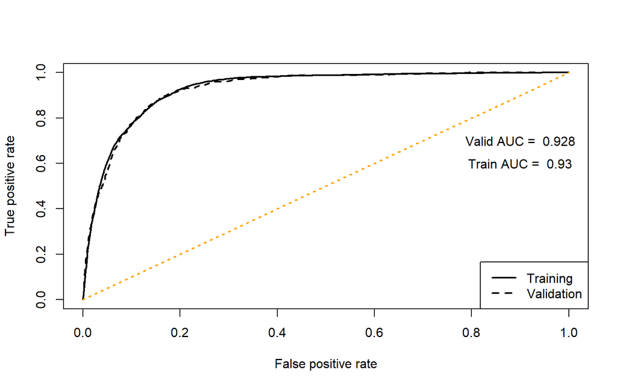

```r
x=y=seq(0,1,0.1)



par(mfrow = c(1,1))
plot(performance(prediction(training1$predictions, training1$yyes),"tpr", "fpr"),lwd = 2, lty = 1)
plot(performance(prediction(validation1$predictions, validation1$yyes),"tpr", "fpr"),add=TRUE, lwd = 2, lty = 2)
lines(x,y,lwd = 2, lty = 3, col = "orange" )
text(0.9, 0.7,paste("Valid AUC = ",round(performance(prediction(validation1$predictions, validation1$yyes),"auc")@y.values[[1]],digit = 3)))
text(0.9, 0.6,paste("Train AUC = ",round(performance(prediction(training1$predictions, training1$yyes),"auc")@y.values[[1]],digit = 3)))
legend("bottomright", c("Training", "Validation"),lwd = 2, lty = 1:2)
```

#### As it is classification problem I decided to find optimal cutoffpoint. In this case opitmal cut off is equal 0.47 however we see that for training data it is on lower level.

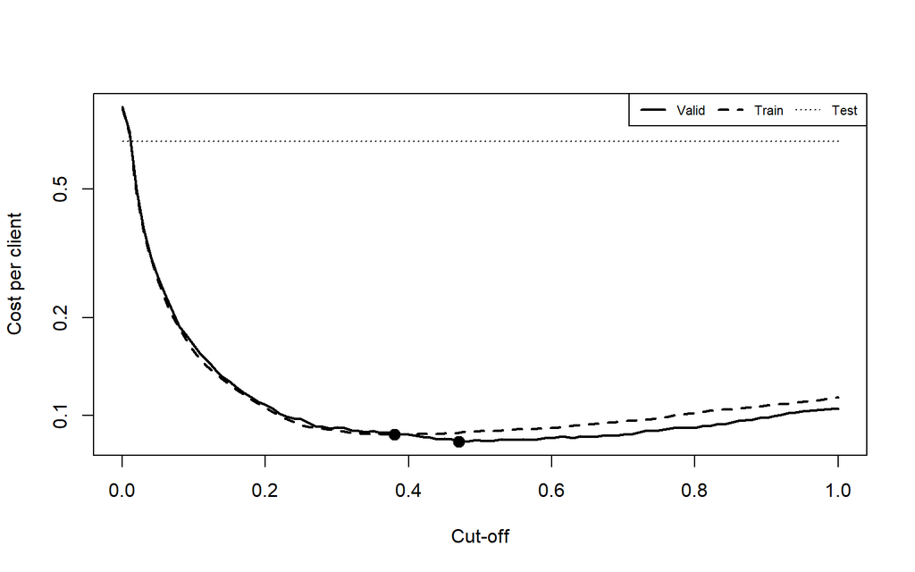

```r
CalculateCost <-function(cut.off, cost.matrix, score, true.y){
  prediction <- ifelse(score > cut.off, 1, 0)
  confusion.matrix <- prop.table(table(factor(prediction, levels = c(0, 1)),
                                       true.y))
  return(sum(cost.matrix * confusion.matrix))
}

cutoffs <- seq(0, 1, by = 0.01)
costmatrix <- matrix(c(0, 1, 1, 0), 2)

score <- costs <- list()

score[[1]] <- validation1$predictions
costs[[1]] <- sapply(cutoffs, CalculateCost, cost.matrix = costmatrix,
                     score = score[[1]], true.y = validation1$yyes)

score[[2]] <- training1$predictions
costs[[2]] <- sapply(cutoffs, CalculateCost, cost.matrix = costmatrix,
                     score = score[[2]], true.y = training1$yyes)


plot(data.frame(cutoffs, 0.7), type = "l", lty = 3, log = "y",
     ylim = range(c(0.7, unlist(costs))),
     ylab = "Cost per client", xlab = "Cut-off")
for (i in 1:2) {
  lines(cutoffs, costs[[i]], lty = i, lwd = 2)
  points(cutoffs[which.min(costs[[i]])], min(costs[[i]]),
         pch = 19, cex = 1.3)
}

legend("topright", c("Valid", "Train", "Test"),
       lty = c(1, 2, 3), cex = .7, ncol = 3,
       lwd = c(2, 2, 1))
```

```r
cutoff_opt_logi <- cutoffs[which.min(costs[[1]])]

cutoff_opt_logi
```

```
## [1] 0.47
```

#### After applying cutoff equal 0.47 let’s check the confusion matrix. We can see that the model slightly better in predicting False values, but performance among Validation and Training set does not differ exstensively.

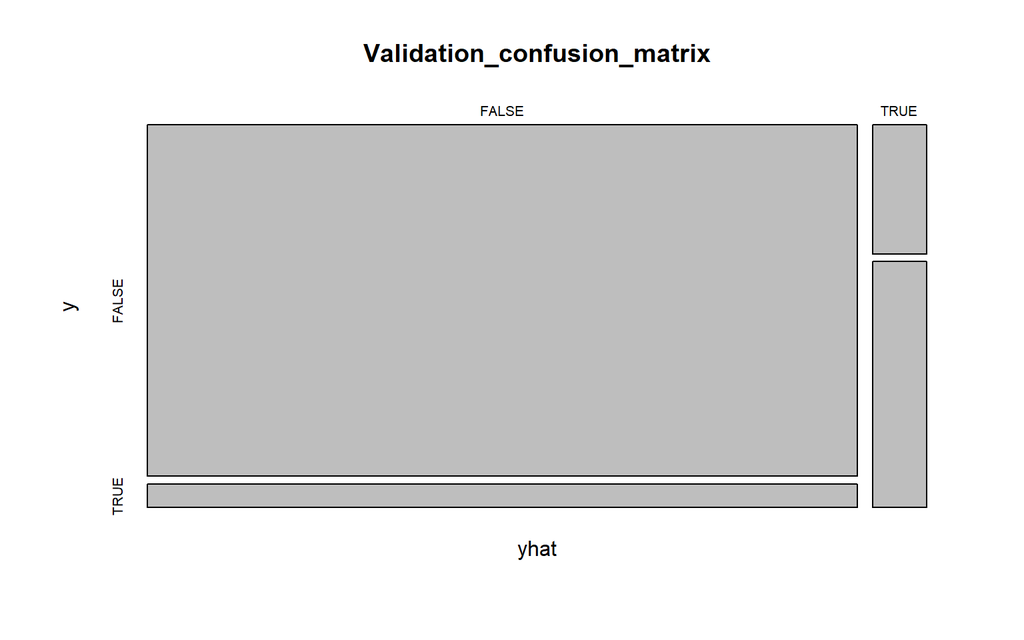

```r
for (i in 1:nrow(training1)){
   if(training1$predictions[i]>cutoff_opt_logi){
     training1$yhat[i] <- TRUE
     training1$yhat[i] <- as.logical(training1$yhat[i])}
  else{
    training1$yhat[i] <- FALSE
    training1$yhat[i] <- as.logical(training1$yhat[i])
  }
}

for (i in 1:nrow(validation1)){
   if(validation1$predictions[i]>cutoff_opt_logi){
     validation1$yhat[i] <- TRUE}
  else{
    validation1$yhat[i] <- FALSE
  }
}

Validation_confusion_matrix<-table(validation1$yhat,validation1$yyes,dnn=c("yhat","y"))
Training_confusion_matrix<-table(training1$yhat,training1$yyes,dnn=c("yhat","y"))
mosaicplot(Validation_confusion_matrix)
```

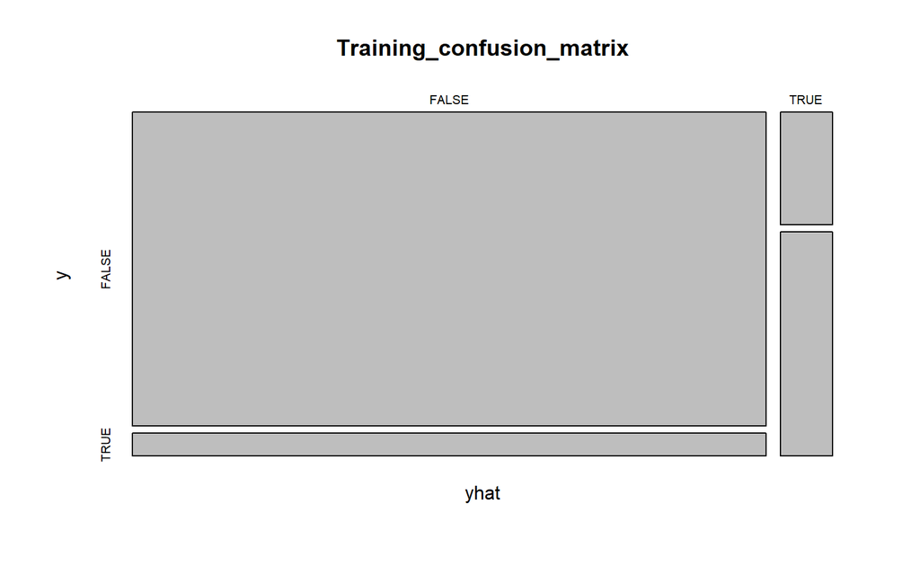

```r
mosaicplot(Training_confusion_matrix)
```

### Decision Tree